# PA1_template

# Reproducible Research: Course Project 1

## Source of data

This assignment makes use of data from a personal activity monitoring device. This device collects data at 5 minute intervals through out the day. The data consists of two months of data from an anonymous individual collected during the months of October and November, 2012 and include the number of steps taken in 5 minute intervals each day.

The dataset can be downloaded from the course website: [Activity Monitoring Data](https://d396qusza40orc.cloudfront.net/repdata%2Fdata%2Factivity.zip)

The variables included in this dataset are:

- **steps:** Number of steps taking in a 5-minute interval (missing values are coded as NA)
- **date:** The date on which the measurement was taken in YYYY-MM-DD format
- **interval:** Identifier for the 5-minute interval in which measurement was taken

The dataset is stored in a comma-separated-value (CSV) file and there are a total of 17,568 observations in this dataset.

## Loading and preprocessing the data

*Make sure that you’ve set your working directory to where the csv file is!*

```r
Activity <- read.csv("activity.csv")
```

## What is mean total number of steps taken per day?

For this part of the assignment, you can ignore the missing values in the dataset.

1. Calculate the total number of steps taken per day.

```r
Total <- aggregate(steps~date, Activity, sum, na.rm=TRUE)
```

2. Make a histogram of the total number of steps taken each day.

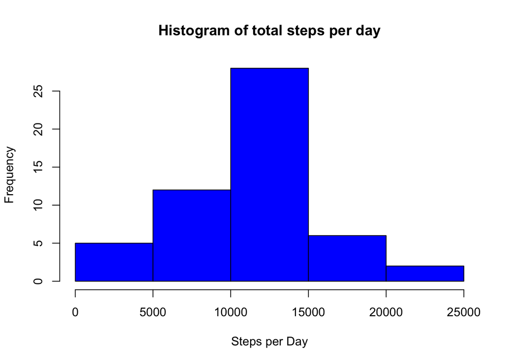

```r
hist(Total$steps,
     main="Histogram of total steps per day",
     xlab="Steps per Day", col="blue")
```

3. Calculate and report the mean and median of the total number of steps taken per day.

```r
mean(Total$steps)
```

```
## [1] 10766.19
```

The mean total number of steps taken per day is **10766.19**.

```r
median(Total$steps)
```

```
## [1] 10765
```

The median total number of steps taken per day is **10765**.

## What is the average daily activity pattern?

1. Make a time series plot (i.e. 𝚝𝚢𝚙𝚎 = “𝚕”) of the 5-minute interval (x-axis) and the average number of steps taken, averaged across all days (y-axis).

[figure not shown]

```r
Total_by_int <-aggregate(steps~interval, Activity, sum, na.rm=TRUE)
library(ggplot2)
ggplot(Total_by_int, aes(x=interval, y=steps)) +
    stat_summary(fun.y="mean", geom="line") +
    labs(title="Average Daily Activity Pattern")
```

2. Which 5-minute interval, on average across all the days in the dataset, contains the maximum number of steps?

```r
Total_by_int[which.max(Total_by_int$steps),]
```

```
##     interval steps
## 104      835 10927
```

Interval **835** has the maximum number of averaged steps across all days.

## Imputing missing values

1. Calculate and report the total number of missing values in the dataset.

```r
sum(is.na(Activity))
```

```
## [1] 2304
```

```r
sum(is.na(Activity$steps))
```

```
## [1] 2304
```

There are **2304** missing values in the dataset. All the missing values are for the variable ‘steps’.

2. Devise a strategy for filling in all of the missing values in the dataset.

The strategy I chose was to replace NA values in steps for a given interval with the *average* number of steps across all days in the same interval. Thus I needed to figure out what the mean number of steps per interval across all days was.

```r
Steps.Int <- aggregate(steps ~ interval, data = Activity, FUN = mean)
```

3. Create a new dataset that is equal to the original dataset but with the missing data filled in.

```r
Activity2 <- merge(Activity, Steps.Int, by="interval")
Activity2$steps.x[is.na(Activity2$steps.x)] <- Activity2$steps.y[is.na(Activity2$steps.x)]
```

Double-checking that the new dataframe no longer has missing values (ie. NA).

```r
sum(is.na(Activity2))
```

```
## [1] 0
```

4a. Make a histogram of the total number of steps taken each day.

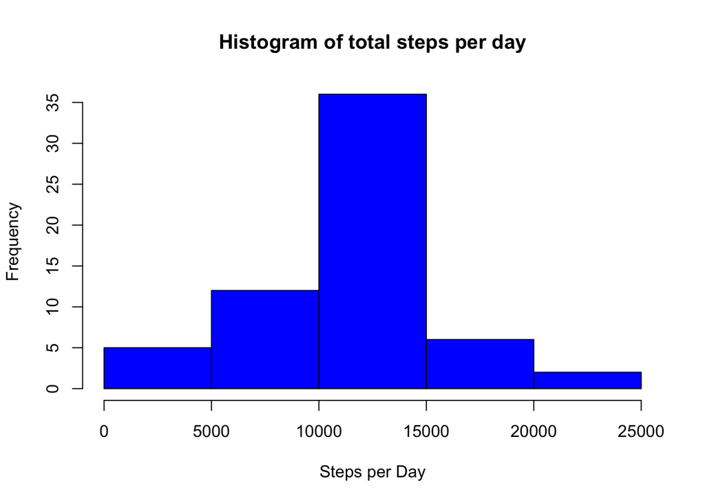

```r
Total2 <- aggregate(steps.x~date, Activity2, sum)
hist(Total2$steps.x,
     main="Histogram of total steps per day",
     xlab="Steps per Day", col="blue")
```

4b. Calculate and report the mean and median total number of steps taken per day.

```r
mean(Total2$steps.x)
```

```
## [1] 10766.19
```

The new mean is **10766.19**.

```r
median(Total2$steps.x)
```

```
## [1] 10766.19
```

The new median is also **10766.19**.

4c. Do these values differ from the estimates from the first part of the assignment? What is the impact of imputing missing data on the estimates of the total daily number of steps?

The mean of the imputed dataset did not change, while the median of the imputed dataset went up slightly and is now the same value as the mean. Comparing the two histograms:

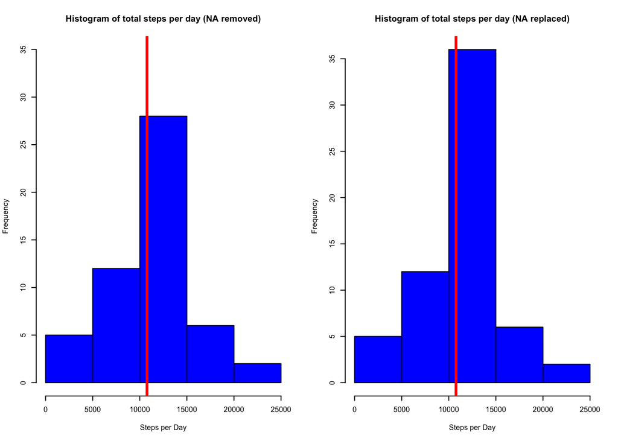

```r
par(mfrow=c(1,2), cex=.5)
hist(Total$steps,
     main="Histogram of total steps per day (NA removed)",
     xlab="Steps per Day", col="blue", ylim=c(0,35))
abline(v = mean(Total$steps), col="red", lwd=3)
hist(Total2$steps.x,
     main="Histogram of total steps per day (NA replaced)",
     xlab="Steps per Day", col="blue")
abline(v = mean(Total2$steps.x), col="red", lwd=3)
```

You can see that the overall shape of the histograms is very similar, however the frequency of the mean number of steps (indicated by vertical red line) is greater in the imputed dataset (NA replaced) than the original dataset (NA removed). This makes sense given that we replaced the NA values with the mean value thus increasing the frequency of the mean value.

## Are there differences in activity patterns between weekdays and weekends?

1. Create a new factor variable in the dataset with two levels – “weekday” and “weekend” indicating whether a given date is a weekday or weekend day.

```r
Activity2$day<- weekdays(as.Date(Activity2$date))
Activity2$day.type <- ifelse(Activity2$day == "Saturday" | Activity2$day == "Sunday",
                             "Weekend", "Weekday")
Activity2$day.type <- factor(Activity2$day.type)
```

2. Make a panel plot containing a time series plot (i.e. 𝚝𝚢𝚙𝚎 = “𝚕”) of the 5-minute interval (x-axis) and the average number of steps taken, averaged across all weekday days or weekend days (y-axis).

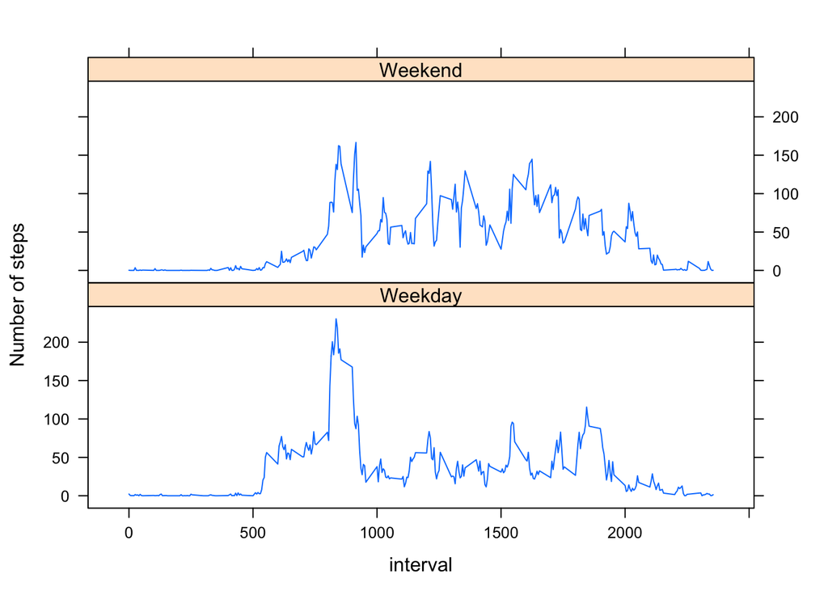

```r
Steps.Int.Day <- aggregate(steps.x ~ interval + day.type, data = Activity2, FUN = mean)
library(lattice)
xyplot(steps.x ~ interval | day.type,
       data=Steps.Int.Day, type='l', layout=c(1,2), ylab="Number of steps")
```